# Investment Strategy Analysis

Monte Carlo Simulation of Multiplicative Investment Games

# 1 Investment Strategy Analysis: Monte Carlo Simulation

## 1.1 Executive Summary

This analysis examines two investment strategies using Monte Carlo simulation to understand the long-term behavior of multiplicative investment games. We investigate how expected value calculations can be misleading when applied to real-world investment scenarios with compounding effects.

**Key Finding**: Despite a positive 5% expected return, most simulations result in significant losses, demonstrating the critical importance of understanding risk distributions rather than relying solely on expected values.

## 1.2 The Investment Game

**Strategy 1: Full Investment**

Consider an investment game where you start with $1,000. Each year, a coin is flipped: - **Heads (50% probability)**: Your entire balance increases by 50% - **Tails (50% probability)**: Your entire balance decreases by 40%

This process continues annually from age 25 to 55 (30 years).

**Risk Profile**: High volatility with potential for massive gains or significant losses.

**Strategy 2: Partial Investment**

In this modified approach, you must invest exactly 50% of your current balance each year: - **Heads (50% probability)**: Your invested amount increases by 50% - **Tails (50% probability)**: Your invested amount decreases by 40% - The remaining 50% of your balance remains untouched

**Risk Profile**: Lower volatility with capital preservation focus.

## 1.3 Analysis Framework

### 1.3.1 Expected Value Analysis

Let’s establish the mathematical foundation for our investment strategies by examining expected values across multiple time horizons:

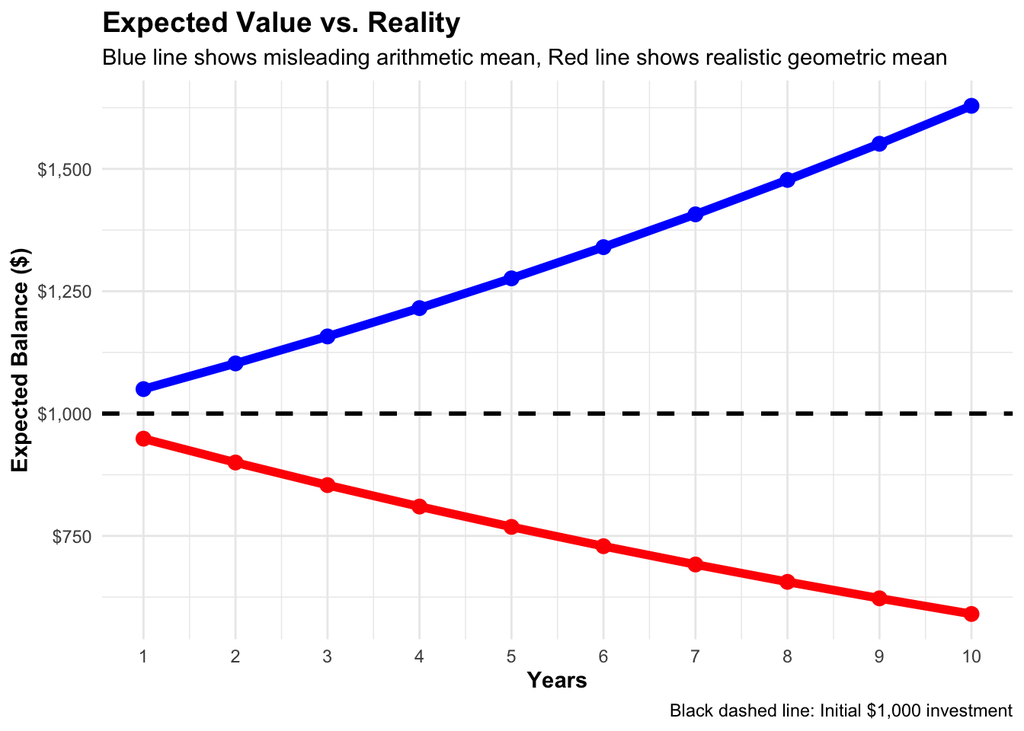

Comprehensive expected value analysis across multiple time horizons

```
=== EXPECTED VALUE ANALYSIS ===
```

```
Single Coin Flip Analysis:
```

```
• Initial balance: $ 1000
```

```
• Balance after heads (+50%): $ 1500
```

```
• Balance after tails (-40%): $ 600
```

```
• Expected value (1 flip): $ 1050
```

```
• Expected return (1 flip):  5 %
```

```
Multi-Year Expected Value Comparison:
```

Expected Value Analysis: Arithmetic vs. Geometric Mean Over Time

| Years | Expected Value | Geometric Mean | Arithmetic Return | Geometric Return |
| --- | --- | --- | --- | --- |
| 1 | $1,050 | $949 | 5% | -5.1% |
| 2 | $1,102 | $900 | 10.2% | -10% |
| 3 | $1,158 | $854 | 15.8% | -14.6% |
| 4 | $1,216 | $810 | 21.6% | -19% |
| 5 | $1,276 | $768 | 27.6% | -23.2% |
| 6 | $1,340 | $729 | 34% | -27.1% |
| 7 | $1,407 | $692 | 40.7% | -30.8% |
| 8 | $1,477 | $656 | 47.7% | -34.4% |
| 9 | $1,551 | $622 | 55.1% | -37.8% |
| 10 | $1,629 | $590 | 62.9% | -41% |

Comprehensive expected value analysis across multiple time horizons

**ImportantKey Insight: The Expected Value Paradox**

**Counter-Intuitive Finding**: Despite positive expected value (+5% per flip), most simulations result in losses due to the multiplicative nature of compounding.

**Mathematical Explanation**: - **Arithmetic Mean**: $1,050 after 1 year (5% expected return) - **Geometric Mean**: $948 after 1 year (-5.2% expected return) - **Reality**: The geometric mean better predicts long-term outcomes in multiplicative processes

**Why This Matters**: The arithmetic mean overestimates returns because it doesn’t account for the compounding effect of losses.

## 1.4 Single Simulation Analysis

Let’s examine what happens in a single 30-year simulation:

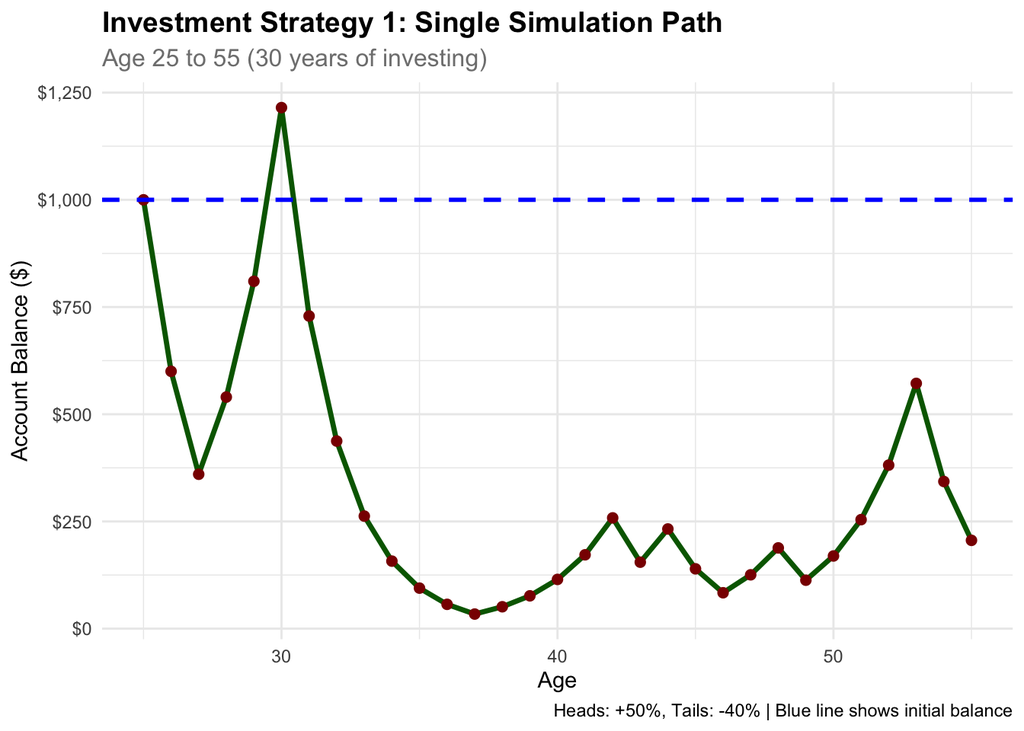

Single 30-year simulation of Strategy 1

```
Single Simulation Results:
```

```
Initial balance (age 25): $ 1000
```

```
Final balance (age 55): $ 205.89
```

```
Total return:  -79.41 %
```

```
Annualized return:  -5.13 %
```

## 1.5 Monte Carlo Analysis: 100 Simulations

To understand the true risk profile, we run 100 simulations:

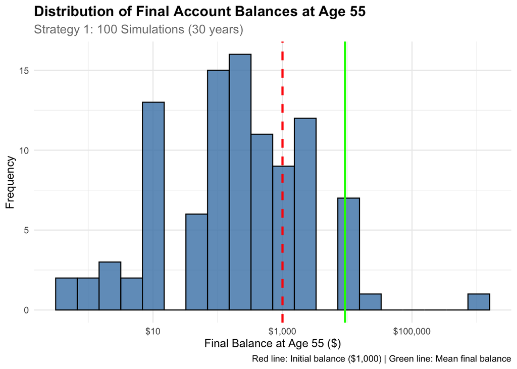

Distribution of final balances from 100 simulations

```
Strategy 1 Summary Statistics:
```

```
# A tibble: 1 × 6
  mean_balance median_balance min_balance max_balance prob_above_initial
         <dbl>          <dbl>       <dbl>       <dbl>              <dbl>
1        9226.           206.       0.337     785412.                0.3
# ℹ 1 more variable: prob_above_10000 <dbl>
```

## 1.6 Probability Analysis

```
Strategy 1 Probability Analysis:
```

```
Probability that final balance > $1,000:  0.3  ( 30 %)
```

```
Probability that final balance > $5,000:  0.09  ( 9 %)
```

```
Probability that final balance > $10,000:  0.02  ( 2 %)
```

```
Probability that final balance > $50,000:  0.01  ( 1 %)
```

```
# A tibble: 4 × 3
  threshold probability percentage
  <chr>           <dbl>      <dbl>
1 $1,000           0.3          30
2 $5,000           0.09          9
3 $10,000          0.02          2
4 $50,000          0.01          1
```

## 1.7 Strategy 2 Analysis: 50% Investment Distribution

Let’s examine the distribution of Strategy 2 results separately:

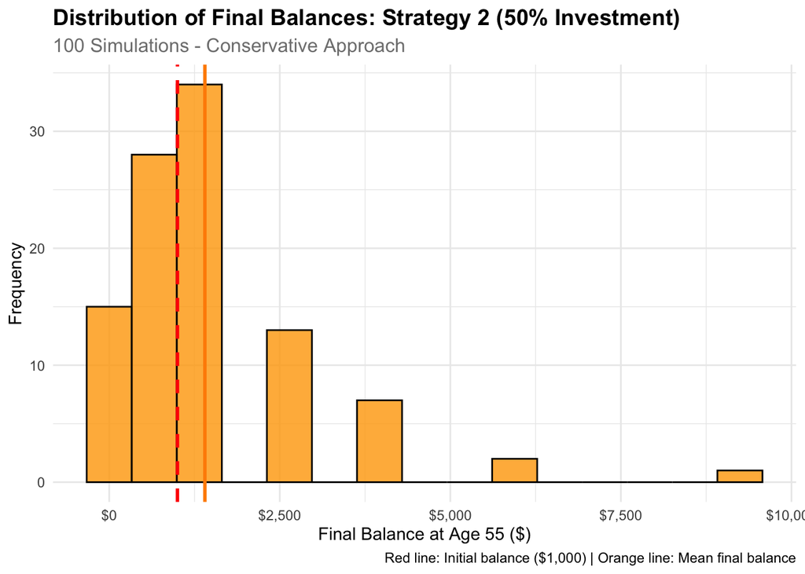

Distribution of Strategy 2 final balances (50% investment rule)

Strategy 2 Summary Statistics (50% Investment Rule)

| Mean Balance | Median Balance | Minimum Balance | Maximum Balance | Chance > $1,000 | Chance > $10,000 |
| --- | --- | --- | --- | --- | --- |
| $1,402 | $1,000 | $68.7 | $9,313 | 39% | 0% |

Distribution of Strategy 2 final balances (50% investment rule)

## 1.8 Strategy Comparison: Side-by-Side Analysis

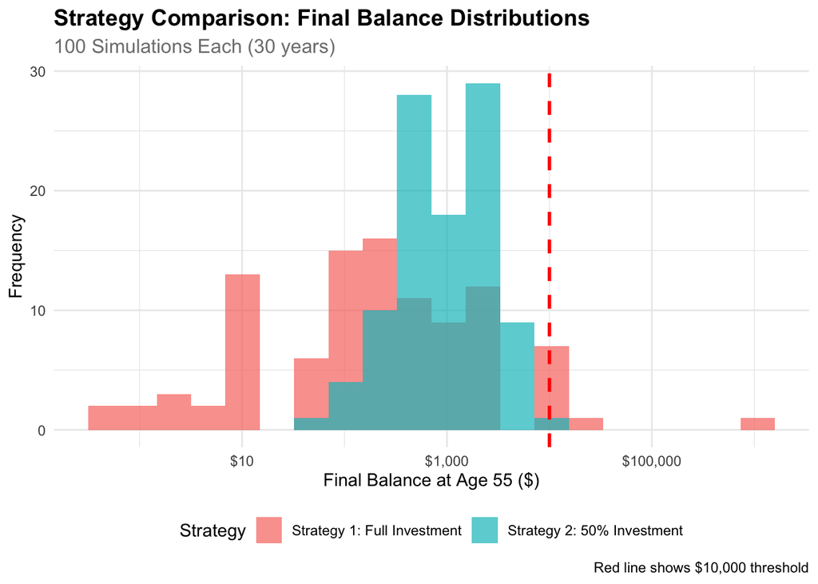

Comparison of Strategy 1 vs Strategy 2

Strategy Comparison: Final Results

| Investment Strategy | Average Final Balance | Median Final Balance | Chance > $1,000 | Chance > $10,000 |
| --- | --- | --- | --- | --- |
| Strategy 1: Full Investment | $9,226 | $ 206 | 30% | 2% |
| Strategy 2: 50% Investment | $1,402 | $1,000 | 39% | 0% |

Comparison of Strategy 1 vs Strategy 2

**Tip🎯 Key Comparison Insights**

**Capital Preservation**: Strategy 2 is safer (39% vs 30% chance of keeping your $1,000)

**Growth Potential**: Strategy 1 offers higher rewards (2% vs 0% chance of reaching $10,000)

**Risk vs Reward**: Full investment is riskier but has potential for massive gains

**Conservative Approach**: 50% investment strategy prioritizes capital preservation over growth

**Strategic Trade-off**: Choose Strategy 1 for maximum upside potential, Strategy 2 for capital protection

## 1.9 Risk-Return Analysis

Let’s create a comprehensive risk-return visualization:

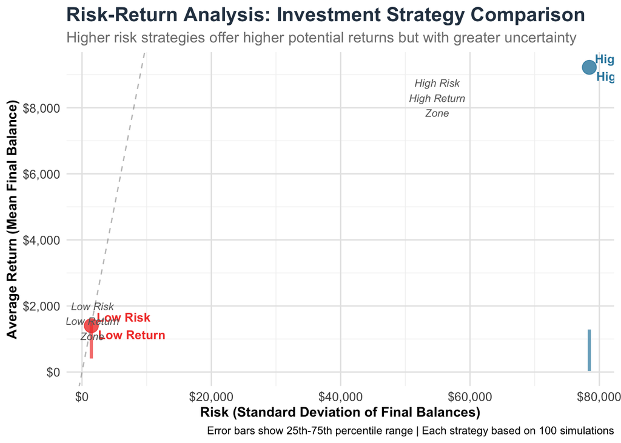

Enhanced Risk-Return Analysis with confidence intervals and distribution comparison

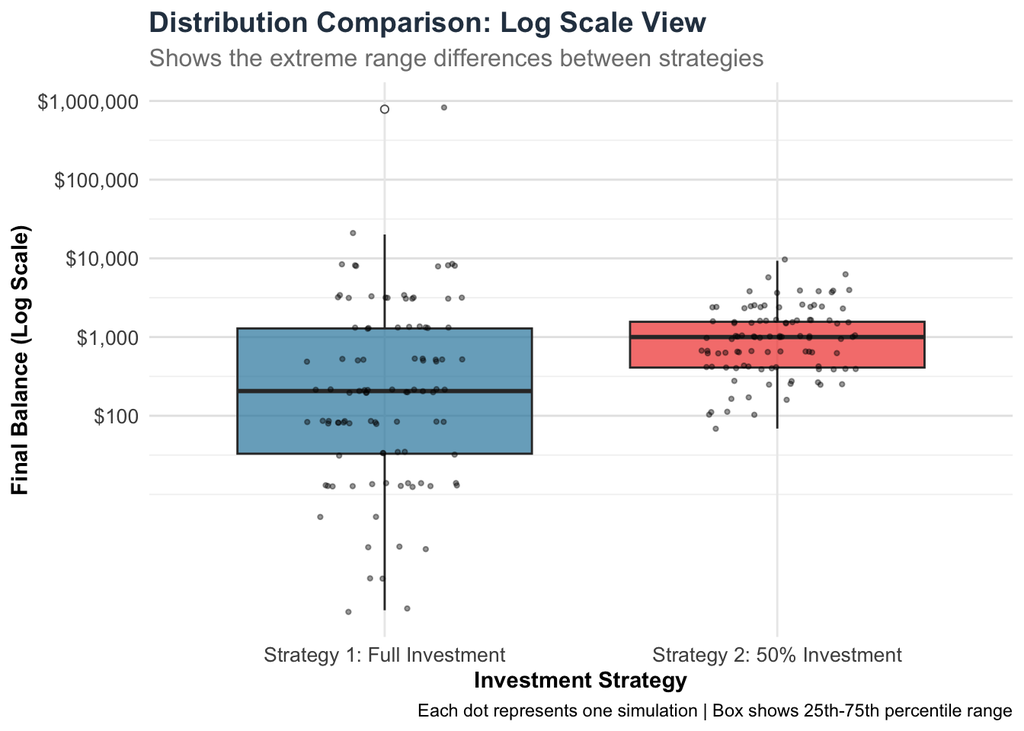

Enhanced Risk-Return Analysis with confidence intervals and distribution comparison

Risk-Return Analysis Summary

| Investment Strategy | Mean Return | Risk (Std Dev) | Minimum Return | Maximum Return | Risk/Return Ratio |
| --- | --- | --- | --- | --- | --- |
| Strategy 1: Full Investment | $9,226 | $78,455 | $ 0.3 | $785,412 | 8.5 |
| Strategy 2: 50% Investment | $1,402 | $ 1,444 | $68.7 | $ 9,313 | 1.03 |

Enhanced Risk-Return Analysis with confidence intervals and distribution comparison

## 1.10 Key Findings

**WarningRisk-Return Analysis**

1. **Expected Value Misleading**: Despite a positive 5% expected return, most simulations result in losses below the initial investment.
2. **Extreme Volatility**: Final balances range from near zero to potentially millions, demonstrating the high-risk nature of multiplicative investment strategies.
3. **Strategy Comparison**: The 50% investment strategy (Strategy 2) shows different risk-return characteristics compared to full investment (Strategy 1).

**NoteProbability Results**

- **Strategy 1 (Full Investment)**:
  - Probability of ending above $1,000: **30%**
  - Probability of ending above $10,000: **2%**
- **Strategy 2 (50% Investment)**:
  - Probability of ending above $1,000: **39%**
  - Probability of ending above $10,000: **0%**

**Key Insight**: Strategy 2 is safer for preserving capital but offers no chance of high returns.

### 1.10.1 Strategic Implications

This analysis demonstrates several critical concepts:

1. **Expected Value vs. Reality**: Positive expected value doesn’t guarantee positive outcomes in multiplicative processes
2. **Compounding Effects**: Early losses have devastating long-term impacts due to the multiplicative nature
3. **Risk Management**: Position sizing and diversification are crucial for managing investment risk
4. **Simulation Power**: Monte Carlo methods reveal the true distribution of possible outcomes

**TipConclusion**

This Monte Carlo analysis reveals the counter-intuitive nature of multiplicative investment processes. While theoretical expected value calculations suggest positive returns, the reality of compounding effects leads to extreme outcomes with high downside risk. Understanding these dynamics is essential for making informed investment decisions and implementing appropriate risk management strategies.

The comparison between full investment and partial investment strategies demonstrates how position sizing can significantly impact risk-return profiles, highlighting the importance of strategic portfolio management in real-world investment scenarios.

**Key Takeaway**: Expected value alone is insufficient for investment decisions - understanding the full distribution of outcomes is crucial for risk management.

### 1.10.2 Strategic Recommendations

1. **For Conservative Investors**: Choose Strategy 2 for better capital preservation
2. **For Risk-Tolerant Investors**: Strategy 1 offers higher potential rewards
3. **For All Investors**: Always analyze the full distribution of outcomes, not just expected values
4. **Portfolio Management**: Consider position sizing and diversification strategies